# Communicate Data findings

- Introduction
- Univariate Exploration.
- Bivariate Exploration
- Multivariate Exploration.

## Introduction

This project explore the mobile Apps that users prefer. This dataset is consisted by variables that help us to reach in plenty of conclusions about what make users spend more money. This dataset being obtaining from free Kaggle datasets called Mobile App Store in CSV format file. Below we can see the exact meaning of column names.

```
1.  "id" : App ID
2.  "track_name": App Name
3.  "size_bytes": Size (in Bytes)
4.  "currency": Currency Type
5.  "price": Price amount
6.  "user_rating" : Average User Rating value (for all version)
7.  "userratingver": Average User Rating value (for current version)
8.  "prime_genre": Primary Genre
9.  "sup_devices.num": Number of supporting devices
10. "lang.num": Number of supported languages
```

```python
#Drop the unneccersy columns from dataset
df.drop(['rating_count_tot','rating_count_ver','user_rating_ver','ver','ipadSc_urls.num','vpp_lic'], axis=1, inplace=True)
df.head()
```

|  | Unnamed: 0 | id | track_name | size_bytes | currency | price | user_rating | cont_rating | prime_genre | sup_devices.num | lang.num |
| --- | --- | --- | --- | --- | --- | --- | --- | --- | --- | --- | --- |
| 0 | 1 | 281656475 | PAC-MAN Premium | 100788224 | USD | 3.99 | 4.0 | 4+ | Games | 38 | 10 |
| 1 | 2 | 281796108 | Evernote - stay organized | 158578688 | USD | 0.00 | 4.0 | 4+ | Productivity | 37 | 23 |
| 2 | 3 | 281940292 | WeatherBug - Local Weather, Radar, Maps, Alerts | 100524032 | USD | 0.00 | 3.5 | 4+ | Weather | 37 | 3 |
| 3 | 4 | 282614216 | eBay: Best App to Buy, Sell, Save! Online Shop... | 128512000 | USD | 0.00 | 4.0 | 12+ | Shopping | 37 | 9 |
| 4 | 5 | 282935706 | Bible | 92774400 | USD | 0.00 | 4.5 | 4+ | Reference | 37 | 45 |

## Univariate Exploration

### Most popular APPS.

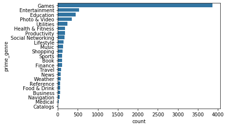

```python
base_color = sb.color_palette()[0]
order = df['prime_genre'].value_counts().index
sb.countplot(data = df, y = 'prime_genre', color = base_color, order = order)
```

The most popular APPS are the games users tend to download more games that other applications.

### Distribution of Price in Game's Apps.

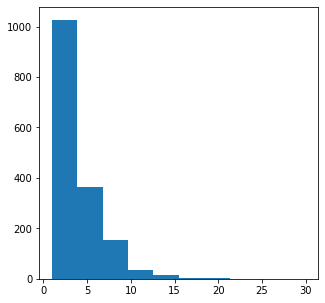

```python
#Define price distribution for Game's APPS.
plt.figure(figsize = [5, 5])
plt.hist(data = df_games, x = 'price')
```

According to the histogram above we could summarize that the game prices are slightly above 0.

### TOP 10 Genre based on the users rating.

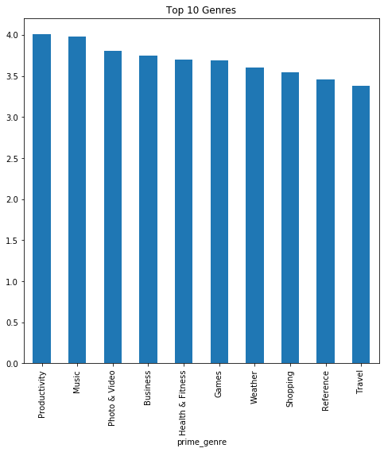

```python
#Create a barchart for the top 10 genres.
# plot Barchart
df_top.plot(kind='bar',figsize=(8,8));
# title
plt.title('Top 10 Genres')
```

Despite the fact that Games are the most most popular among the users. Genres of Productivity & Music get higher user's rating than Games.

## Bivariate Exploration

> In this section, investigate relationships between pairs of variables in your data. Make sure the variables that you cover here have been introduced in some fashion in the previous section (univariate exploration).

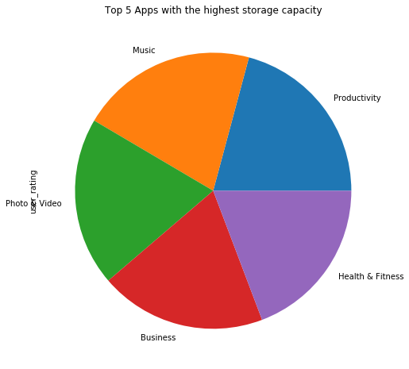

```python
# code for the pie chart seen above
#Create a piechart for the top 5 genres with highest size_bytes.
# plot piechart
df_top2.plot(kind='pie',figsize=(8,8));
# title
plt.title('Top 5 Apps with the highest storage capacity')
```

### Violin plot based on top 5 APPS highest mobile Apps storage capacity

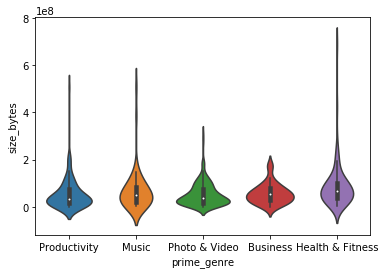

```python
# Create violin plot for
sb.violinplot(data = df_out, x = 'prime_genre', y = 'size_bytes')
```

Based on Health & Fitness APPS have the highest size distribution and Bussiness APPS are the most normal distributed.

### Prices based on Apps Genres.

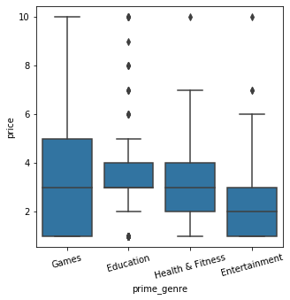

```python
# Create box plot
plt.figure(figsize = [5, 5])
base_color = sb.color_palette()[0]
sb.boxplot(data = df_out, x = 'prime_genre', y = 'price', color = base_color)
# Rotate the labels.
plt.xticks(rotation=15);
```

The above boxplot indicate as that games have the highest price while Enterainment apps charge the less.Moreove,the average prices of (Games,Education,Health & Fitness) have quit similar value.

## Multivariate Exploration.

> Create plots of three or more variables to investigate your data even further. Make sure that your investigations are justified, and follow from your work in the previous sections.

### Multiple Correlation.

The below process indicate as the coefficient of values in multiple correlation format.

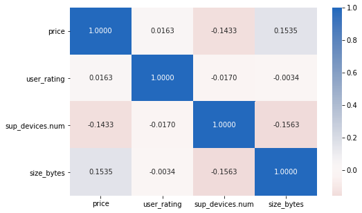

```python
# correlation for 'price', 'user_rating', 'sup_devices.num','size_bytes'
plt.figure(figsize = [8, 5])
sb.heatmap(df_ch[vars].corr(), annot = True, fmt = '.4f',
           cmap = 'vlag_r', center = 0)
plt.show()
```

In the above Heatmap we can compare the correlation between the variables (price', 'user_rating', 'sup_devices.num','size_bytes'). An unexpected finding is that there is a negative correlation between the price and the number of supported devices. That means that an App which could be supported by different types of devices is not so expensive than other which is supported by less.